# Open science

## Open methods increase data value

**Before each click:** which of these would open methods make better?

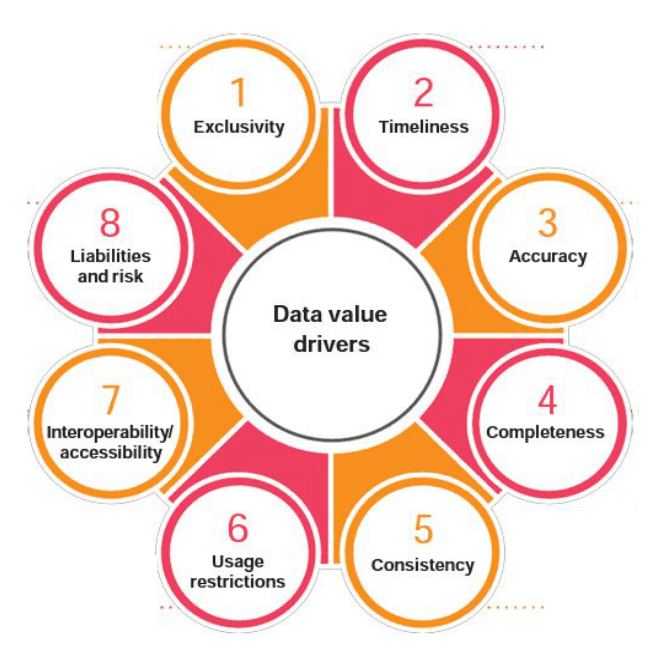

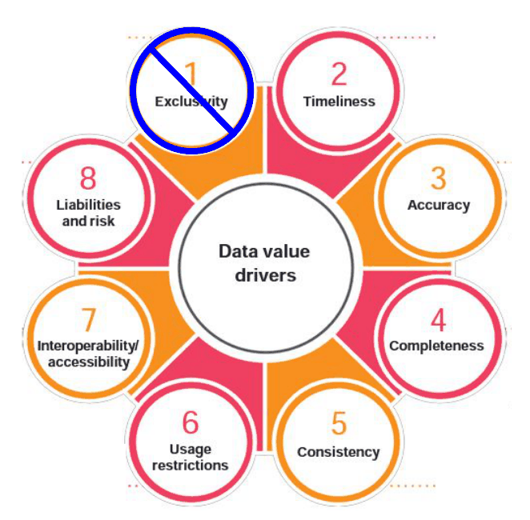

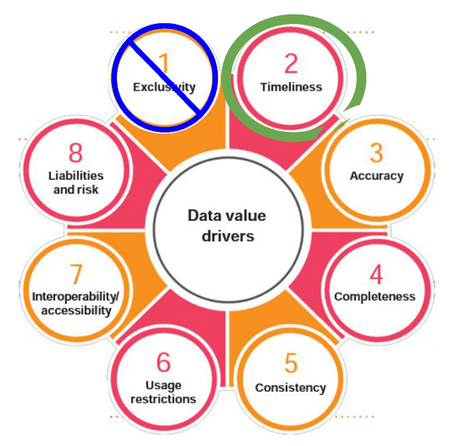

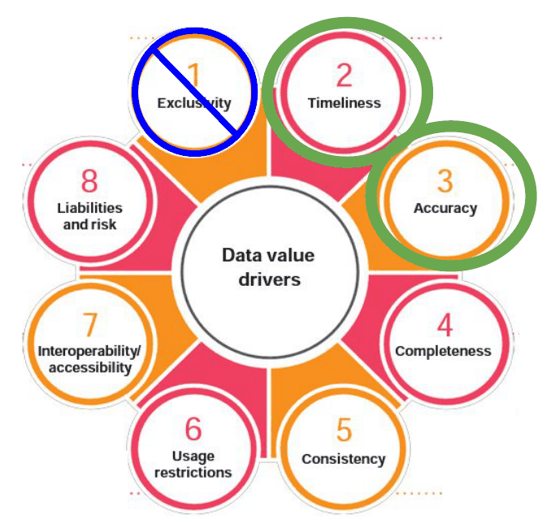

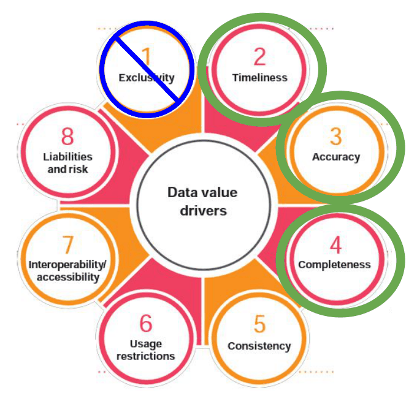

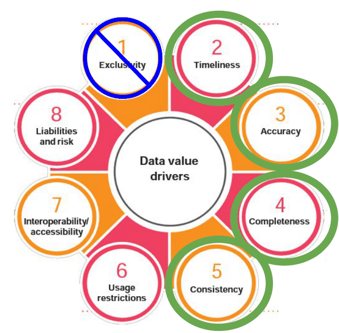

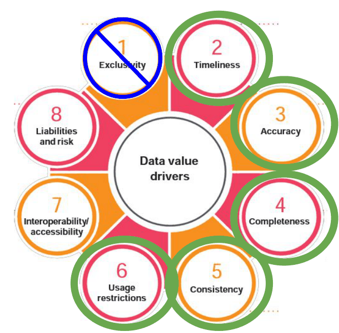

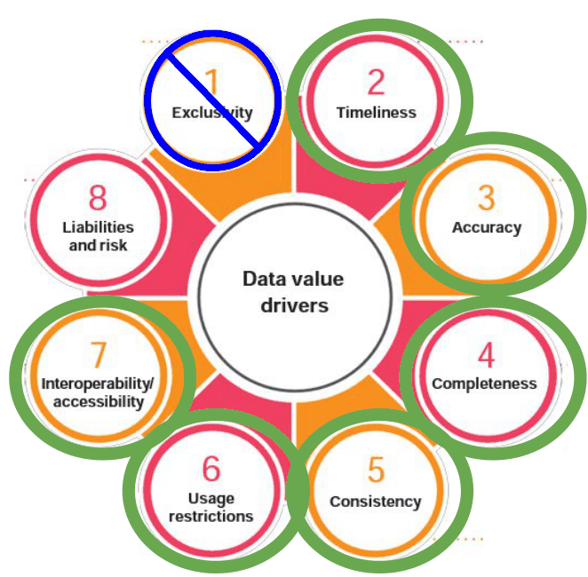

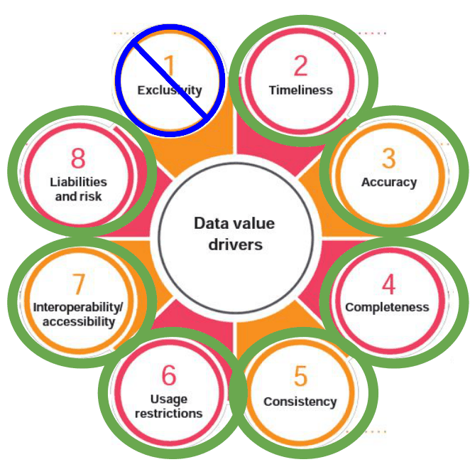

PwC, *Putting a value on data*: pwc.co.uk/data-analytics/documents/putting-value-on-data.pdf

## Methods papers are highly cited

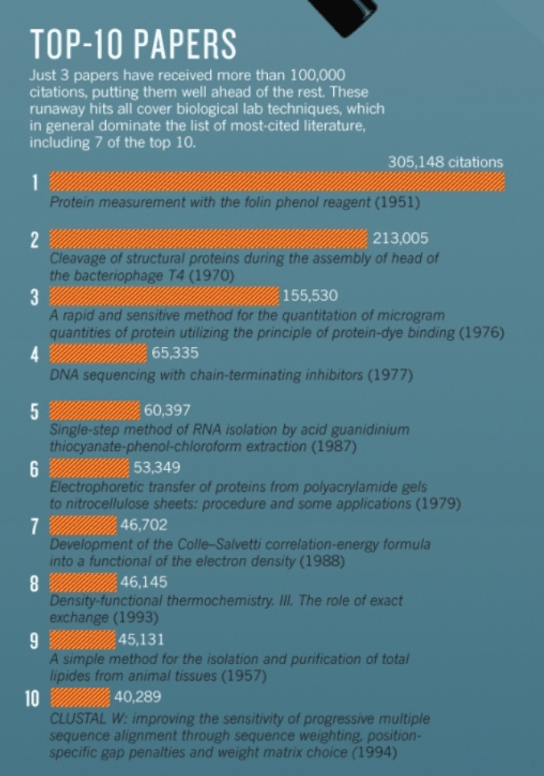

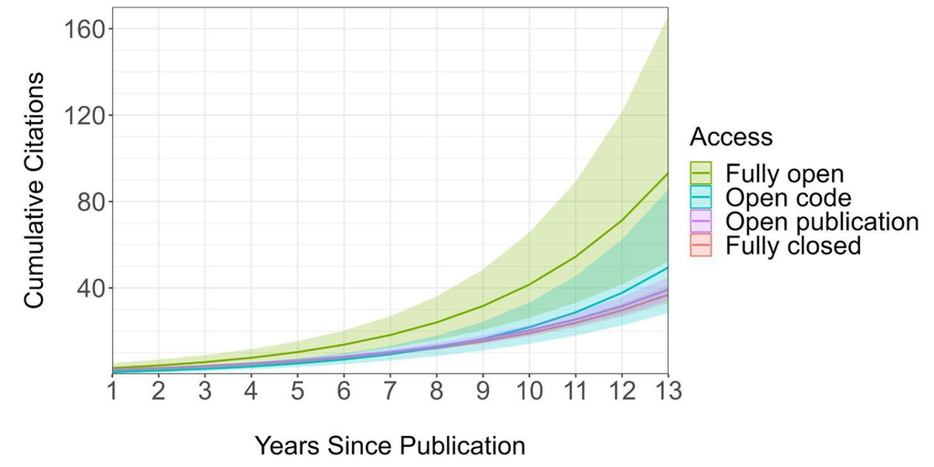

(as are open access papers, so presumably open methods will be especially successful?)

Van Noorden et al. (2014) *Nature*

## What is Open Science?

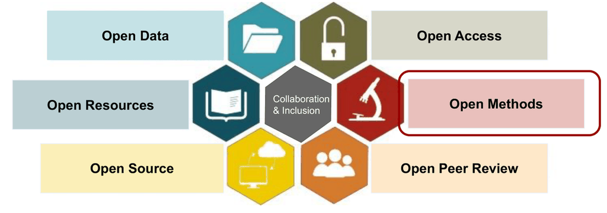

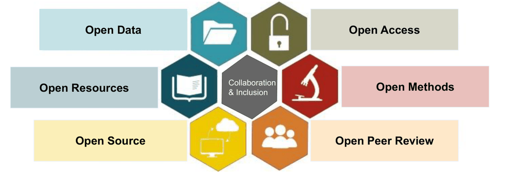

Gallagher et al. (2020) *Nature Ecology & Evolution*

# Wrapping up

## Back to your list

**Which of your reasons not to share did today answer?**

| Worry | From today |
| --- | --- |
| my code is messy | messy shared code beats none (Peng’s spectrum) |
| someone will scoop me | a DOI makes it citable, and repositories can embargo data until your paper is out |
| the data are sensitive | share what you can: metadata, or coarsened locations; some data shouldn’t be fully open |
| they’re not my data | ask the owner; you can still share your code |
| I don’t know how | Zenodo, Dryad, OSF or Figshare for data; GitHub plus Zenodo for code |

## Which tool, when

| You want to | Do this |
| --- | --- |
| keep your data safe and findable | deposit it in a repository, in more than one place |
| get credit for a dataset | a DOI from the repository, or a data paper |
| share code others can run | GitHub, archived on Zenodo, with the five D’s from Lecture 28 |
| analysis software anyone can use | open source: R, Python, QGIS, Julia |
| results others can compare with yours | shared protocols and metadata standards |
| more citations | share your data, code and methods |

## Remainder of class

Coding time in class (optional).

**Before the final:** prepare your presentations.